# Where are plastics going

Yuhang Zheng

August 10, 2018

## I. Introduction

Human activities brings increasing burden to the environment. One of the most obvious signs are the tons of trash and wastes that human society generated. With the rapid industrialization and urban expansion, it is foreseeable that the amount of trash will keep soaring [1]. Some types of the trash greatly threaten the global ecosystem, for example, plastics pose undeniable threat to the oceans [2], kills the marine animals, and in turn will impact human health [3]. Some of the trashes would take hundreds of years to degrade. Knowing the severe situation of trash is beneficiary for us to take further actions to help the environment.

The United States is among one of the leading countries that produce the most trash. To understand what is the situation of waste management in the United States can help us have a better picture of the general circumstances of this field.

The questions that this project is trying to answer:

1. what are the most common types of the trash collected along the seashore.
2. what exact locations are those trash found.
3. what is the general situations of the entire life cycles of plastic products in USA. How many was generated, how many was recycled, combusted, and landfilled.

## II. Data and Methods

### Data Source:

#### 1. Marine Debris dataset

The data of trash collected along the seashore is from Marine Debris Tracker, a program from a joint partnership of [NOAA Marine Debris Program](https://marinedebris.noaa.gov/) and [Southeast Atlantic Marine Debris Unitiative](http://sea-mdi.engr.uga.edu) at University of Georgia. It is a platform where people can log the data of what trash they collect and remove along the sea shore. This project only download the most recent trash collecting records from 01/01/2018 - 07/31/2018, which contains 47400 rows of records. Each row representing a piece of trash collected.

The colums that would be used in this project are as following:

- itemName: name of collected trash item, for example: Metal Bottle Caps, Plastic or Foam Fragments, etc.
- Latitude
- longitude
- Quantity
- Material Description

##### 2.Key facts and figures of materials and wastement management in USA

the tabs that would be used in this project:

- Materials generated
- Materials recycled
- Materials combusted
- Materials landfilled
- Products generated contain&pkg
- Products recycled contain&pkg
- Products combusted contain&pkg
- Products landfilled contain&pkg

### Method:

Various different analytics and visualization techniques would be leveraged, such as bar chart, map, line chart, Sankey chart, etc.

- Using bar charts to show the amount of materials/trash for each different genre.
- Using bar charts or pie charts to show the proportion of different type of trashes found along the coastal area.
- Using map to plot the location where the trash was found and logged by individuals along the coastal area.
- Using area chart to visualize the relationship among materials generated, materials recycled, materials combusted, and materials landfilled. Sankey chart will provide an intuitive way to show the situation of waste management.
- Using time series charts to demonstrate the amount changes of materials generated, materials recycled, materials combusted, and materials landfilled along the year from 1960 to 2014.

The data from Marine Debris Tracker would requires additional data cleaning and aggregation before analysis, such as missing value checking, grouping, generating new column, etc.

## III. Data Analysis and Visualization

Prepare dataset

```r
library(readxl)
library(ggplot2)
library(leaflet)
library(dplyr)
library(reshape2)

setwd("./data/")
marine_debris <- read.csv("mdt_data_jan_jul_2018.csv")
```

```r
materials_generated <- read_excel("./data/MATERIALS_MUNICIPAL_WASTE_STREAM_1960_TO_2014.xlsx", sheet = "Materials generated")
materials_generated <- materials_generated[1:17,]
materials_recycled <- read_excel("./data/MATERIALS_MUNICIPAL_WASTE_STREAM_1960_TO_2014.xlsx", sheet = "Materials recycled")
materials_recycled <- materials_recycled[1:17, ]
materials_combusted <- read_excel("./data/MATERIALS_MUNICIPAL_WASTE_STREAM_1960_TO_2014.xlsx", sheet = "Material combusted")
materials_combusted <- materials_combusted[1:17, ]
materials_landfilled <- read_excel("./data/MATERIALS_MUNICIPAL_WASTE_STREAM_1960_TO_2014.xlsx", sheet = "Materials landfilled")
materials_landfilled <- materials_landfilled[1:17, ]


container_generated <- read_excel("./data/MATERIALS_MUNICIPAL_WASTE_STREAM_1960_TO_2014.xlsx",
    sheet = "Products generated contain&pkg")
container_generated <- container_generated[1:38, ]
container_recycled <- read_excel("./data/MATERIALS_MUNICIPAL_WASTE_STREAM_1960_TO_2014.xlsx",
    sheet = "Products recycled contain&pkg")
container_recycled <- container_recycled[1:38, ]
container_combusted <- read_excel("./data/MATERIALS_MUNICIPAL_WASTE_STREAM_1960_TO_2014.xlsx",
    sheet = "Products combusted contain&pkg")
container_combusted <- container_combusted[1:38, ]
container_landfilled <- read_excel("./data/MATERIALS_MUNICIPAL_WASTE_STREAM_1960_TO_2014.xlsx",
    sheet = "Products landfilled contain&pkg")
container_landfilled <- container_landfilled[1:38, ]
```

A statistic summary of marine debris dataset

```r
print(str(marine_debris))
```

```
## 'data.frame':    47400 obs. of  15 variables:
##  $ ListID              : int  22 22 22 22 22 22 22 22 22 22 ...
##  $ ListName            : Factor w/ 1 level "Marine Debris Items": 1 1 1 1 1 1 1 1 1 1 ...
##  $ ItemID              : int  182 202 181 187 178 187 202 202 202 202 ...
##  $ ItemName            : Factor w/ 37 levels "Aerosol cans",..: 17 28 26 6 3 6 28 28 28 28 ...
##  $ LogID               : int  232744 232745 233043 233044 233045 233046 233047 233048 233049 233050 ...
##  $ Latitude            : num  32.9 32.9 31.1 31.1 31.1 ...
##  $ Longitude           : num  -115.1 -115.1 -81.4 -81.4 -81.4 ...
##  $ Altitude            : num  54.5 55.7 5.8 5.8 5.8 ...
##  $ Quantity            : int  1 16 2 1 1 1 1 1 1 1 ...
##  $ Error.Radius        : num  4.29 3.22 5 5 5 ...
##  $ Timestamp           : num  2.02e+13 2.02e+13 2.02e+13 2.02e+13 2.02e+13 ...
##  $ Location            : Factor w/ 114 levels "","Amman, Amman Governorate",..: 13 13 106 106 106 106 106 106 106 106 ...
##  $ Description         : Factor w/ 1943 levels ""," Clear meso film ",..: 1 1 1 1 1 1 1 1 1 1 ...
##  $ Material.ID         : int  2 4 4 4 4 4 4 4 4 4 ...
##  $ Material.Description: Factor w/ 8 levels "CLOTH","FISHING GEAR",..: 4 7 7 7 7 7 7 7 7 7 ...
## NULL
```

```r
print(summary(marine_debris))
```

```
##      ListID                  ListName         ItemID
##  Min.   :22   Marine Debris Items:47400   Min.   :174
##  1st Qu.:22                               1st Qu.:187
##  Median :22                               Median :198
##  Mean   :22                               Mean   :195
##  3rd Qu.:22                               3rd Qu.:202
##  Max.   :22                               Max.   :220
##
##                              ItemName         LogID
##  Plastic or Foam Fragments       : 9782   Min.   :232744
##  Plastic Food Wrappers           : 4767   1st Qu.:251841
##  Cigarettes                      : 4321   Median :266847
##  Plastic rope / Small Net Pieces : 3976   Mean   :266388
##  Other                           : 3420   3rd Qu.:281756
##  Plastic Bottle or Container Caps: 2907   Max.   :298832
##  (Other)                         :18227
##     Latitude        Longitude          Altitude           Quantity
##  Min.   :-16.93   Min.   :-156.04   Min.   :-365.483   Min.   :   1.000
##  1st Qu.: 35.86   1st Qu.:-122.22   1st Qu.:   1.054   1st Qu.:   1.000
##  Median : 37.96   Median : -81.31   Median :   4.231   Median :   1.000
##  Mean   : 39.91   Mean   : -89.21   Mean   :  22.706   Mean   :   2.417
##  3rd Qu.: 46.92   3rd Qu.: -54.09   3rd Qu.:  11.489   3rd Qu.:   1.000
##  Max.   : 55.97   Max.   : 145.78   Max.   :1953.968   Max.   :2500.000
##
##   Error.Radius       Timestamp                       Location
##  Min.   :   2.00   Min.   :2.018e+13                     :14400
##  1st Qu.:   5.00   1st Qu.:2.018e+13   unknown, unknown  : 6923
##  Median :   5.00   Median :2.018e+13   Oakland, CA       : 5777
##  Mean   :  29.68   Mean   :2.018e+13   San Pablo, CA     : 3884
##  3rd Qu.:   6.00   3rd Qu.:2.018e+13   Raleigh, NC       : 2567
##  Max.   :9751.07   Max.   :2.018e+13   Come By Chance, NL: 2084
##                                        (Other)           :11765
##   Description     Material.ID        Material.Description
##         :38143   Min.   :1.000   PLASTIC       :30669
##  Film   :  962   1st Qu.:4.000   FISHING GEAR  : 5044
##  Thread :  584   Median :4.000   PAPER & LUMBER: 4367
##  Hard   :  291   Mean   :4.078   OTHER ITEMS   : 3696
##  Film   :  269   3rd Qu.:4.000   METAL         : 1315
##  T      :  269   Max.   :9.000   GLASS         : 1122
##  (Other): 6882                   (Other)       : 1187
```

#### 1. what are the most common types of the trash collected along the seashore.

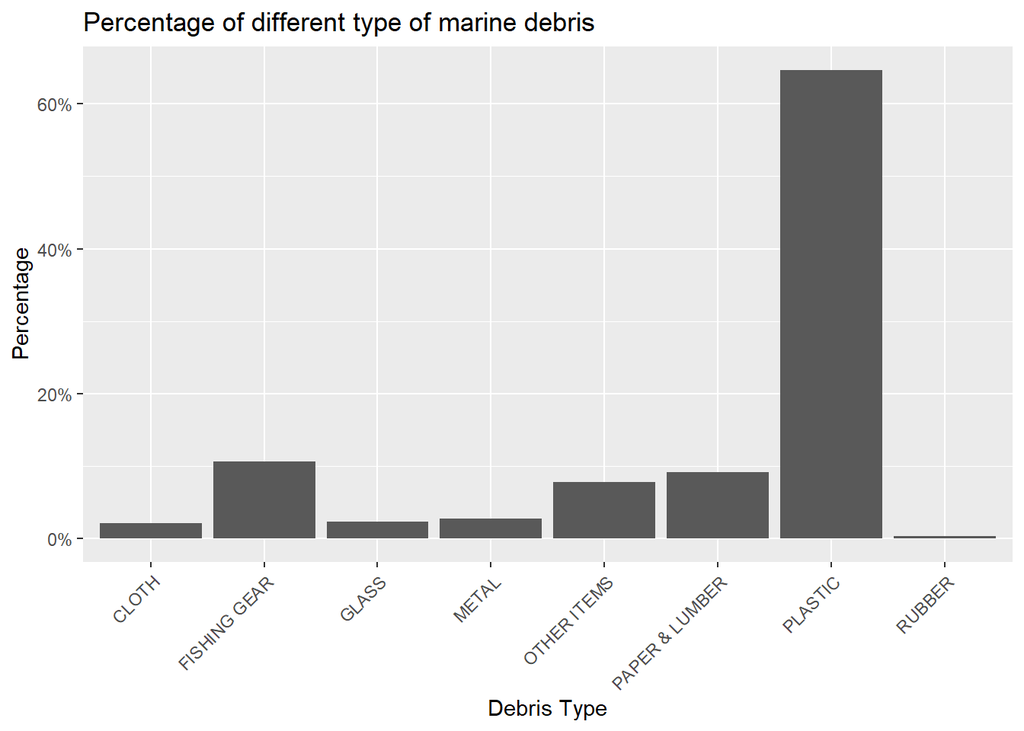

```r
ggplot(marine_debris) + geom_bar(aes(x=marine_debris$Material.Description, y=(..count..)/sum(..count..))) + scale_y_continuous(labels = scales::percent)+theme(axis.text.x=element_text(angle=45, hjust=1))+labs(y='Percentage', title='Percentage of different type of marine debris', x="Debris Type")
```

It is obvious that Plastic is the most common trash among marine debris. More than 60% of trash collected are plastic. The column of ‘itemName’ describes the detailed sub category of each type of debris. The following chart extracts rows identified as ‘Plastic’ and drills down to see what is the percentage of different plastic debris.

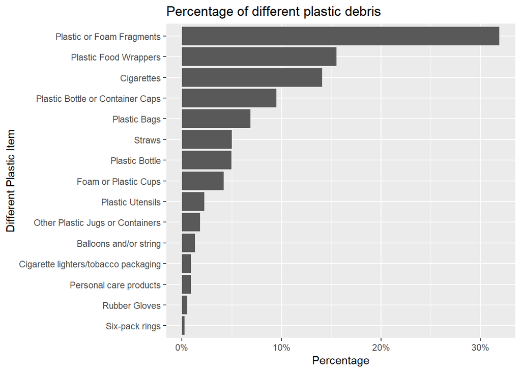

```r
plastic_debris <- marine_debris%>%filter(Material.Description=='PLASTIC')%>%group_by(ItemName)%>%summarise(n=n())%>%mutate(percentage = n/sum(n))%>%arrange(-percentage)

ggplot(plastic_debris)+geom_bar(aes(x=reorder(ItemName, percentage), y=percentage),stat = "identity") + scale_y_continuous(labels = scales::percent)+coord_flip()+labs(y='Percentage', x='Different Plastic Item', title='Percentage of different plastic debris')
```

The horizontal bar chart above plots the percentage of different type of plastic debris collected, in descending order. The top 5 plastic debirs are plastic or foam fragments, plastic food wrappers, cigarettes, plastic bottle or container caps, plastic bags.

#### 2. East coast or west coast, which do the marine debris mostly collected from

```r
debris_map_data <- marine_debris
debris_map_data$Latitude <- round(marine_debris$Latitude, 2)
debris_map_data$Longitude <- round(marine_debris$Longitude, 2)
debris_map_data <- debris_map_data %>% group_by(Longitude, Latitude)%>%summarise(total = sum(Quantity))

trash_map <- leaflet(debris_map_data)%>%addProviderTiles(providers$CartoDB.Positron, options=providerTileOptions(minZoom=3))%>%fitBounds(lng1=-129.90,lat1=48.47,lng2=-74.30, lat2=15.10)%>%addCircles(lng=~Longitude, lat=~Latitude, radius=~sqrt(total)*1000, weight=1)

trash_map
```

[interactive chart not shown]

Because there are over 40000 records in the dataset, plotting all of them indivudually is not too practical. The records are first grouped by the same lantitude and longitude. Each circle represents a group of records, and the size shows the quantity of debris collected. We can tell that east coast has more records than west coast. The largest amount of debris is collected at St Piere and Miquelon and Florida.

#### 3. How many products were generated and how many plastic products were generated in USA

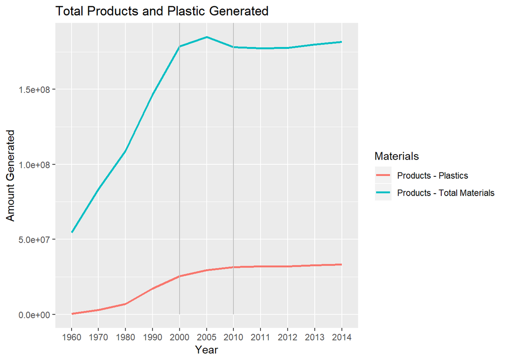

```r
total_and_plastic_generated <- materials_generated%>%filter(Materials %in% (c('Products - Plastics','Products - Total Materials')))

total_and_plastic_generated_melt <- melt(total_and_plastic_generated, id=c("Materials"))
total_and_plastic_generated_melt$Materials <- as.factor(total_and_plastic_generated_melt$Materials)

ggplot(total_and_plastic_generated_melt, aes(variable, value, group=Materials))+geom_line(aes(color=Materials), size=1)+labs(x="Year", y="Amount Generated", title="Total Products and Plastic Generated")+annotate("segment", x=5, xend=5, y=0, yend=Inf, color="grey")+annotate("segment", x=7,xend=7, y=0, yend=Inf, color="grey")
```

The ‘Year’ is not in identical interval, so two vertical lines were added to show the correct segmentation for easy interpretation. From 1960 to 2000, the amount of products generated was soring, so as the plastic generated with less dramastic trend. The total products generated has a small drop during 2005-2010, then became stable. The amount of plastic generated was steady after 2010.

```r
plastic_generated <- materials_generated%>%filter(Materials =='Products - Plastics')
plastic_generated$Materials <- 'generated'
plastic_recycled <- materials_recycled%>%filter(Materials =='Products - Plastics')
plastic_recycled$Materials <- 'recycled'
plastic_combusted <- materials_combusted %>%filter(Materials =='Products - Plastics')
plastic_combusted$Materials <- 'combusted'
plastic_landfilled <- materials_landfilled %>%filter(Materials =='Products - Plastics')
plastic_landfilled$Materials <- 'landfilled'
plastic_lifecycle <- rbind(plastic_recycled,plastic_combusted,plastic_landfilled)
colnames(plastic_lifecycle)[1] <- 'lifecycle'
```

```r
row_names <- plastic_lifecycle[,1]
plastic_lifecycle <- plastic_lifecycle[,-1]

generated <-plastic_generated[,-1]
generated <- as.matrix(generated)
generated <- apply(generated,2,function(c) rep(c,3))

plastic_lifecycle <- as.data.frame(as.matrix(plastic_lifecycle)/generated)
plastic_lifecycle <- cbind(plastic_lifecycle, row_names)
```

#### 4. How many plastic products were recycled, combusted or landfilled?

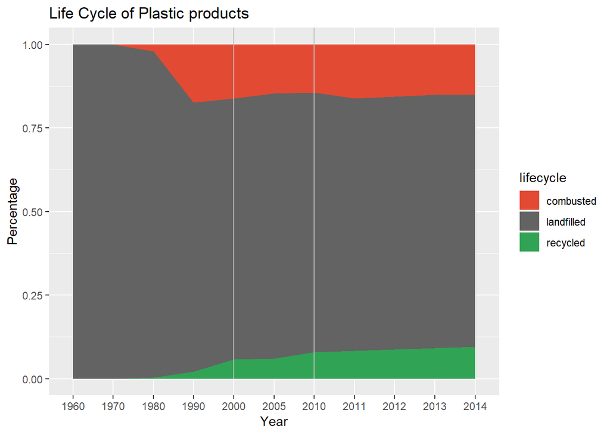

```r
plastic_lifecycle_melt <- melt(plastic_lifecycle, id=c('lifecycle'))
fill_color = c("#e34a33", "#636363","#31a354")
ggplot(plastic_lifecycle_melt,aes(x=variable, y=value,group=lifecycle, fill=lifecycle))+geom_area(position="fill")+scale_fill_manual(values=fill_color)+labs(x="Year", y="Percentage", title="Life Cycle of Plastic products")+annotate("segment", x=5, xend=5, y=0, yend=Inf, color="grey")+annotate("segment", x=7,xend=7, y=0, yend=Inf, color="grey")
```

The above stacked area chart represents the percentage of plastic combusted, recycled, and landfilled from 1960-2014. From the previous line chart of plastic generated, we know that plastic generation increase greatly from 1960 to 2000, then the amount produced became stable. The stacked area chart above shows that before 1990 most of the plastic trash are either landfilled or combusted. Recycling plastic starts around 1980. For the recent decades, the percentage of recylce does not seem improved too much. Landfill is still the most common way to process plastic trash.

#### 5. How many different type of plastic containers were produced?

```r
plastic_container_generated <- container_generated[24:29,]
plastic_container_recycled <- container_recycled[24:29,]
plastic_container_combusted <- container_combusted[24:29,]
plastic_container_landfilled <- container_landfilled[24:29,]
```

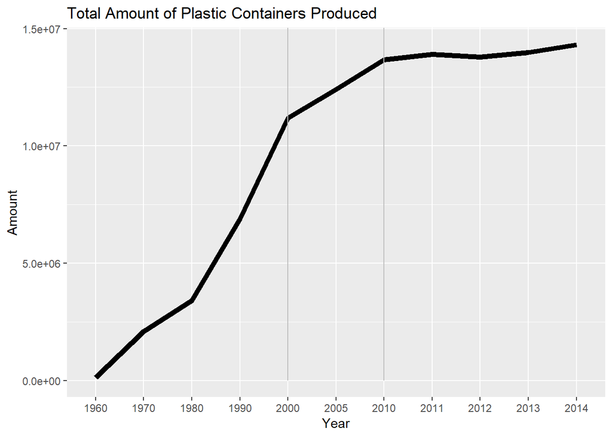

```r
simple_name <- c("PET Bottles and Jars","HDPE Natural Bottles","Other Containers"," Bags, Sacks, and Wraps","Other Plastics Packaging","Total")
plastic_container_generated$Products <- simple_name
total_plastic_container <- plastic_container_generated[6,]
total_plastic_container <- melt(total_plastic_container, id=c("Products"))

ggplot(total_plastic_container, aes(variable, value, group=1))+geom_line(size=2)+annotate("segment", x=5, xend=5, y=0, yend=Inf, color="grey")+annotate("segment", x=7,xend=7, y=0, yend=Inf, color="grey")+labs(x="Year", y="Amount", title="Total Amount of Plastic Containers Produced")
```

The amount of plastic containers keeps increasing. After year 2010, the amount of plastic containers produced seems stable.

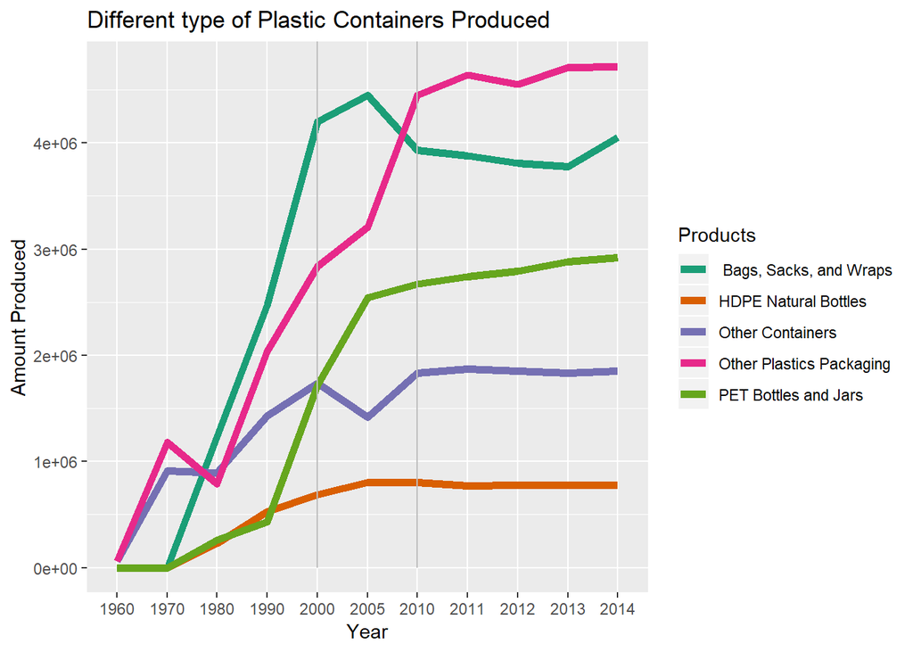

```r
plastic_container_generated_melt <- melt(plastic_container_generated[-6,], id=c("Products"))

ggplot(plastic_container_generated_melt, aes(variable, value, group=Products))+geom_line(aes(color=Products), size=2)+annotate("segment", x=5, xend=5, y=0, yend=Inf, color="grey")+annotate("segment", x=7,xend=7, y=0, yend=Inf, color="grey")+labs(x="Year", y="Amount Produced", title="Different type of Plastic Containers Produced")+scale_color_brewer(palette="Dark2")
```

The amount of plastic bags, sacks,and wraps was decreasing after year 2010. In general, they all keep growing and the amount became stable after 2010.

#### 6. What is the life cycle of different plastic containers?

```r
plastic_container_recycled<-plastic_container_recycled%>%mutate(lifecycle = rep(c('recycled'), times=6))
plastic_container_combusted<-plastic_container_combusted%>%mutate(lifecycle = rep(c('combusted'), times=6))
plastic_container_landfilled<-plastic_container_landfilled%>%mutate(lifecycle = rep(c('landfilled'), times=6))
plastic_container_generated<-plastic_container_generated%>%mutate(lifecycle = rep(c('generated'), times=6))

plastic_container_recycled$Products<-simple_name
plastic_container_combusted$Products<-simple_name
plastic_container_landfilled$Products <- simple_name
plastic_container_generated$Products<-simple_name
```

```r
plastic_container_recycled[,2:12]<-plastic_container_recycled[,2:12]/plastic_container_generated[,2:12]
plastic_container_recycled[is.na(plastic_container_recycled)] <- 0

plastic_container_combusted[,2:12]<-plastic_container_combusted[,2:12]/plastic_container_generated[,2:12]
plastic_container_combusted[is.na(plastic_container_combusted)] <- 0

plastic_container_landfilled[,2:12]<-plastic_container_landfilled[,2:12]/plastic_container_generated[,2:12]
plastic_container_landfilled[is.na(plastic_container_landfilled)] <- 0
```

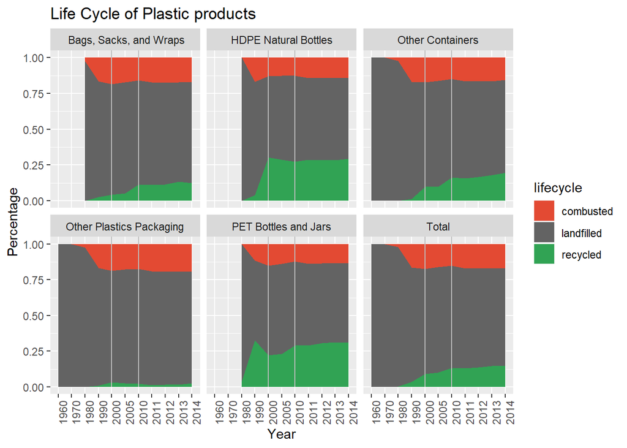

```r
plastic_container <- rbind(plastic_container_recycled, plastic_container_landfilled, plastic_container_combusted)
plastic_container <- melt(plastic_container, id=c('lifecycle', 'Products'))
fill_color = c("#e34a33", "#636363","#31a354")
plastic_container_life_chart <- ggplot(plastic_container, aes(x=variable, y=value, group=lifecycle, fill=lifecycle))+geom_area(position = "fill")+scale_fill_manual(values=fill_color)+facet_wrap(~Products)
plastic_container_life_chart <- plastic_container_life_chart +labs(x="Year", y="Percentage", title="Life Cycle of Plastic products")+annotate("segment", x=5, xend=5, y=0, yend=Inf, color="grey")+annotate("segment", x=7,xend=7, y=0, yend=Inf, color="grey") + theme(axis.text.x=element_text(angle=90, hjust=1))

plastic_container_life_chart
```

HDPE natural bottles, and PET bottles and Jars have higher recycling rate than their combusted rate. Bags, sacks and wraps has higher combusted rate than recycling rate. In general most of the plastic containers were landfilled. Surprisingly it seems the rate of combusted, recycled, and landfilled are pretty stable after year 2000, which also means the USA does not improve too much on plastic recycling.

## V. Reference

[1] Simmons, Ann M. (2016, April 22). The world’s trash crisis, and why many Americans are oblivious. Retrieved from http://www.latimes.com [2] Aloy, A.B., Vallejo, B.M. & Juinio-Meñez, M.A. (2011) Increased plastic litter cover affects the foraging activity of the sandy intertidal gastropod Nassarius pullus. Marine Pollution Bulletin 62:1772-1779. [3] Parker, Laura. (2017, July 19). A Whopping 91% of plastic isn’t recycled. Retrieved from https://news.nationalgeographic.com